# Predicting the Manner of Exercise

Jim VanOosten

December 22, 2015

## Summary

The goal of this project is to use exogenous data to predict the manner in which an exercise was performed. Training and testing data sets were provided for the project. After loading the training data, it is tidied by removing the columns that are not used in the model training. The training data was split for cross validation into a training set (60%) and a probe set (40%). The model was trained using the Random Forest algorithm and its accuracy was found to be over 99% using the probe data. As a final verification, the model was used to correctly predict 20 tests provided in the testing data set.

## Data Processing

- Class A: exactly according to the specification
- Class B: throwing the elbows to the front
- Class C: lifting the dumbbell only halfway
- Class D: lowering the dumbbell only halfway
- Class E: throwing the hips to the front

The sensor data was recorded by accelerometers on the participant’s belt, forearm, arm, and dumbell. For more detail see http://groupware.les.inf.puc-rio.br/har.

### Loading the data

The training data is downloaded using the provided URL and put into a dataframe object.

```r
  setwd("~/Documents/coursera/datascience/predmachlearn/project/practicalmachinelearning")
  set.seed(327)

  # Verify the pml-training.csv has been downloaded
  if (!file.exists("pml-training.csv")) {
    dataUrl = "https://d396qusza40orc.cloudfront.net/predmachlearn/pml-training.csv"
    download.file(dataUrl, destfile = "pml-training.csv", method = "curl")
  }

  # load the data in the pmltrain dataframe
  pmltrain <- read.csv("pml-training.csv", header = TRUE)
  dim(pmltrain)
```

```
## [1] 19622   160
```

### Feature Selection

The training data is tidied by removing columns not used to train the model. Normally the testing data would not be used to influence the prediction model, however, the discussion forums (https://class.coursera.org/predmachlearn-035/forum/thread?thread_id=2) revealed that the test data columns that had NA values could not be used as predictors as they would cause errors if included in the model. Thus the test columns with all NAs are pruned from the training data.

```r
  # Verify the pml-testing.csv has been downloaded
  if (!file.exists("pml-testing.csv")) {
    dataUrl = "https://d396qusza40orc.cloudfront.net/predmachlearn/pml-testing.csv"
    download.file(dataUrl, destfile = "pml-testing.csv", method = "curl")
  }

  # load the data in the test dataframe
  pmltest <- read.csv("pml-testing.csv", header = TRUE)
  dim(pmltest)
```

```
## [1]  20 160
```

```r
  # get a list of the test columns with NA in the column
  na_names <- names(pmltest[, colSums(is.na(pmltest)) == nrow(pmltest)])

  # remove columns from the training set that are NA in the test set
  pmltrain <- pmltrain[,-which(names(pmltrain) %in% na_names)]
```

In addition, I removed user_name, time stamps, and window columns as predictors so the model would be based solely on the sensor data. Keeping the user_name and window number would have made placement of the test frame trivial because the training data is more like a movie while the test data is like a frame from that movie. The names of the remaining variables are shown.

```r
  # only keep the sensor based columns and the classe
  pmltrain <- select(pmltrain, roll_belt:classe)
  names(pmltrain)
```

```
##  [1] "roll_belt"            "pitch_belt"           "yaw_belt"
##  [4] "total_accel_belt"     "gyros_belt_x"         "gyros_belt_y"
##  [7] "gyros_belt_z"         "accel_belt_x"         "accel_belt_y"
## [10] "accel_belt_z"         "magnet_belt_x"        "magnet_belt_y"
## [13] "magnet_belt_z"        "roll_arm"             "pitch_arm"
## [16] "yaw_arm"              "total_accel_arm"      "gyros_arm_x"
## [19] "gyros_arm_y"          "gyros_arm_z"          "accel_arm_x"
## [22] "accel_arm_y"          "accel_arm_z"          "magnet_arm_x"
## [25] "magnet_arm_y"         "magnet_arm_z"         "roll_dumbbell"
## [28] "pitch_dumbbell"       "yaw_dumbbell"         "total_accel_dumbbell"
## [31] "gyros_dumbbell_x"     "gyros_dumbbell_y"     "gyros_dumbbell_z"
## [34] "accel_dumbbell_x"     "accel_dumbbell_y"     "accel_dumbbell_z"
## [37] "magnet_dumbbell_x"    "magnet_dumbbell_y"    "magnet_dumbbell_z"
## [40] "roll_forearm"         "pitch_forearm"        "yaw_forearm"
## [43] "total_accel_forearm"  "gyros_forearm_x"      "gyros_forearm_y"
## [46] "gyros_forearm_z"      "accel_forearm_x"      "accel_forearm_y"
## [49] "accel_forearm_z"      "magnet_forearm_x"     "magnet_forearm_y"
## [52] "magnet_forearm_z"     "classe"
```

### Data Exploration

Exploring the sensor data provides clues on how it can be used to classify the exercises. The plot below shows the roll_belt vs pitch_belt variables while using the classe to color the data.

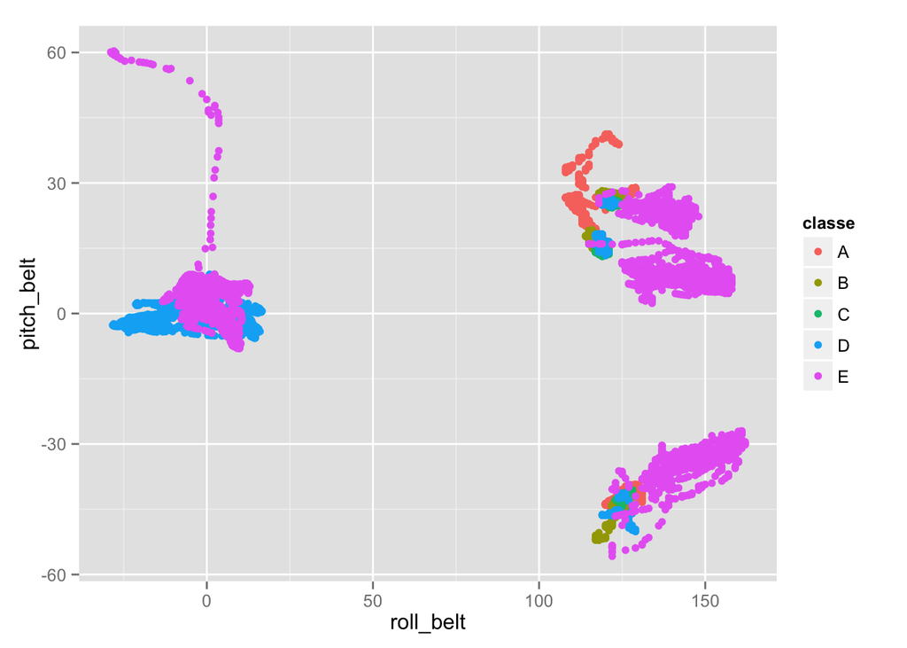

```r
  library(ggplot2)
  qplot(roll_belt,pitch_belt,colour=classe,data=pmltrain)
```

Class E is distinguished from the other classes in the plot which makes sense since the accelerometer on the belt would record the action of throwing the hips to the front.

### Cross Validation

The training set is split into two data sets using the standard 60/40 split of the data for cross validation. The 60% split is used for training while the 40% split will be used to probe the model and estimate the out of sample error before the final test.

```r
  inTrain <- createDataPartition(y=pmltrain$classe, p=0.60, list=FALSE)
  training <- pmltrain[inTrain,]
  dim(training)
```

```
## [1] 11776    53
```

```r
  probing <- pmltrain[-inTrain,]
  dim(probing)
```

```
## [1] 7846   53
```

## Model Creation and Verification

### Model Creation

I selected Random Forest algorithm to create the model. The Random Forest algorithm grows many classification trees, forming a forest, from which the tree with the most votes (based on its classification results) is selected. All of the sensor based columns that remain in the training data set are used as predictors while the classe variable is the outcome.

The doMC package is used to exploit the multiple cores on my work station during the model creation. The doMC uses the parallel package to fork processes and split computations. As a result, the model creation completes in a fraction of the time versus the single core execution.

```r
  library(doMC)
  registerDoMC(cores = 6)
  modFit <- train(classe ~ ., data=training, method="rf")
```

### Model Verification and Accuracy

The probe data set that was set aside for cross validation is used to gauge the model accuracy. The confusion matrix shows the matrix of the predictions versus the reference Classes A-E. The diagonal represents correct predictions and the rows show which category a given prediction actually belonged in. The accuracy of the model was over 99%. Statistics are provided on a per Class basis including the sensitivity and specificity.

```r
  predictions <- predict(modFit, probing)
  confusionMatrix(predictions,probing$classe)
```

```
## Confusion Matrix and Statistics
##
##           Reference
## Prediction    A    B    C    D    E
##          A 2232   10    0    0    0
##          B    0 1499   16    0    0
##          C    0    9 1347   19    0
##          D    0    0    5 1266    1
##          E    0    0    0    1 1441
##
## Overall Statistics
##
##                Accuracy : 0.9922
##                  95% CI : (0.99, 0.994)
##     No Information Rate : 0.2845
##     P-Value [Acc > NIR] : < 2.2e-16
##
##                   Kappa : 0.9902
##  Mcnemar's Test P-Value : NA
##
## Statistics by Class:
##
##                      Class: A Class: B Class: C Class: D Class: E
## Sensitivity            1.0000   0.9875   0.9846   0.9844   0.9993
## Specificity            0.9982   0.9975   0.9957   0.9991   0.9998
## Pos Pred Value         0.9955   0.9894   0.9796   0.9953   0.9993
## Neg Pred Value         1.0000   0.9970   0.9968   0.9970   0.9998
## Prevalence             0.2845   0.1935   0.1744   0.1639   0.1838
## Detection Rate         0.2845   0.1911   0.1717   0.1614   0.1837
## Detection Prevalence   0.2858   0.1931   0.1752   0.1621   0.1838
## Balanced Accuracy      0.9991   0.9925   0.9902   0.9918   0.9996
```

### Out of Sample Error

The out of sample error is the error rate observed on the probing data which is 100% - accuracy = 100% - 99.22% = .78%.

## Final Test

The machine learning algorithm created above is applied to the 20 test cases provided in the test data. The results are saved to files for project submission. They are 100% correct.

```r
  predictfinal <- predict(modFit, pmltest)
  predictfinal
```

```
##  [1] B A B A A E D B A A B C B A E E A B B B
## Levels: A B C D E
```

```r
  results <- "./results"
  if(!file.exists(results)) {dir.create(results)}

  pml_write_files = function(x,y){
    n = length(x)
    for(i in 1:n){
      filename = paste(y,"/problem_id_",i,".txt",sep="")
      write.table(x[i],file=filename,quote=FALSE,row.names=FALSE,col.names=FALSE)
    }
  }

  pml_write_files(predictfinal,results)
```